# Lakásvásárlási döntés

## Working directory meghatározása

## adatok beolvasása

```r
if (!require('readxl')) install.packages('readxl'); library('readxl')
lakasok <- read_excel("ingatlanok.xlsx", sheet = "lakasok")
```

### Szükséges adatátalakitások, tisztitás

… Mintegy másfél éve lakásvásárláson gondolkodtam, és próbáltam ésszerűsíteni a keresést, választást. Ezért letöltöttem a www.ingatlan.com weboldalról mintegy 500 budapesti lakáshirdetést (MS Power Query segítségével), és egy excelbe rendeztem ezeket. Most a korábbi manuális válogast / szubjektív mérlegelést próbálom a tanult módszerek alapján helyettesíteni az R-ben felépített modellel. A cél, hogy egy kb 10 darabból alló listát állítsunk össze, ami leginkább előnyös lehet a saját szempontjaink szerint.  
Az adatbázis már tisztitott, nincsenek hiányzó adatok, hibás datok, ezért adattisztitásra nincs szükség. A korábbi adatfeldolgozásk alkalmával már létrehoztam egy számitott oszlopot azért, hogy a preferenciánkat a lokációra vonatkozóan könnyebben kezelhessem. Három kategóriára osztottam a kerületeket: 1 kat: XIII, IV. 2 kat: V, VI, VII, II, III 3 kat: összes többi kerület (vagyis legszivesebben a XIII. vagy a IV. kerületben laknék).

Ezen kívül hazsnálnánk még a lakás árát, négyzetméterárát, területét, a szobák számát.Összesen tehát 5 döntési szempontunk van.  
Vizsgáljuk meg a döntési szempontjainkként használt változók eloszlását!

Szerencsére sok lakás takálható az első számú preferencia-kerületekben. Jellemző a 2-3 szobás, 50 M2 feletti lakás, 750 eFT és 1 mio Ft/m2 közötti áron.

```r
str(lakasok)
```

```
tibble [500 x 16] (S3: tbl_df/tbl/data.frame)
 $ AR                    : num [1:500] 62 118.9 48.4 49.9 74.9 ...
 $ NEGYZETMETER_AR       : num [1:500] 607843 1213265 949020 845763 788421 ...
 $ VAROS                 : chr [1:500] "Budapest" "Budapest" "Budapest" "Budapest" ...
 $ KERULET               : chr [1:500] "II. kerület" "II. kerület" "II. kerület" "II. kerület" ...
 $ CIM                   : chr [1:500] "Lipthay utca" "Varsányi Irén utca" "Frankel Leó út" "Fillér utca" ...
 $ TERULET               : num [1:500] 102 98 51 59 95 77 140 94 58 130 ...
 $ SZOBAK_SZAMA          : num [1:500] 3 2 1 2 3 2 3 2 2 3 ...
 $ FELSZOBAK_SZAMA       : num [1:500] 0 3 0 0 1 1 1 2 0 2 ...
 $ ERKELY_TERULETE       : num [1:500] 0 0 0 0 0 0 22 4 1.7 24 ...
 $ TELJES_CIM            : chr [1:500] "Budapest Lipthay utca" "Budapest Varsányi Irén utca" "Budapest Frankel Leó út" "Budapest Fillér utca" ...
 $ ATLAGOS_KERULETI_NMAR : num [1:500] 945065 945065 945065 945065 945065 ...
 $ KERULETI_LAKASOK_SZAMA: num [1:500] 23 23 23 23 23 23 23 23 23 23 ...
 $ prediction            : num [1:500] 90.7 79 57.2 60.8 81.8 ...
 $ Érdekes               : chr [1:500] "Igen" "Nem" "Nem" "Igen" ...
 $ ELTERES               : num [1:500] 0.4635 -0.3354 0.1809 0.2184 0.0919 ...
 $ KERULET_PREFERNCIA    : num [1:500] 2 2 2 2 2 2 2 2 2 2 ...
```

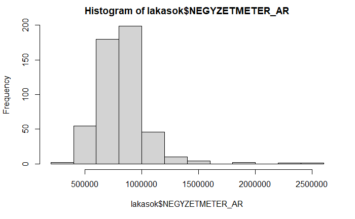

```r
if (!require('tidyverse')) install.packages('tidyverse'); library('tidyverse')
if (!require('reshape2')) install.packages('reshape2'); library('reshape2')

hist(lakasok$NEGYZETMETER_AR)
```

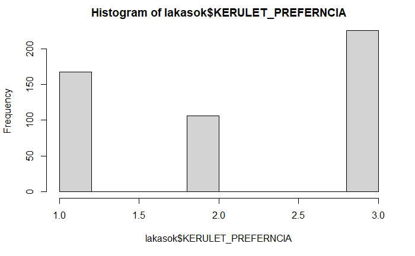

```r
hist(lakasok$KERULET_PREFERNCIA)
```

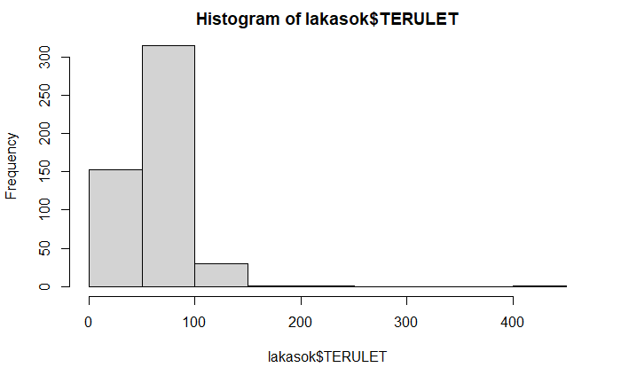

```r
hist(lakasok$TERULET)
```

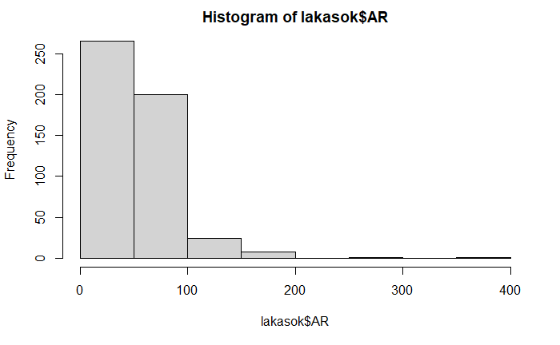

```r
hist(lakasok$AR)
```

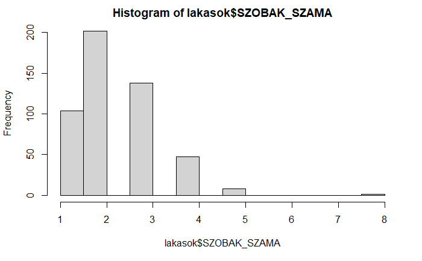

```r
hist(lakasok$SZOBAK_SZAMA)
```

### Minimumfeltételeknek nem megfelelő esetek kizárása

…Maximum 60 millió forintot tudunk szánni a vásárlásra, és legalább 2 szobás lakást szeretnénk. Ezért szűrjük le az adatbázisunkat az ezeknek megfelelő lakásokra! 225 ezekek a minimumfeltételeknek megfelelő lakás van a táblánkban.

```r
if (!require('DT')) install.packages('DT'); library('DT')


Decision.Alternatives.1 <- subset(lakasok, `AR` <= 60 & `SZOBAK_SZAMA` > 1, select = c(`AR`, `NEGYZETMETER_AR`, `SZOBAK_SZAMA`, `KERULET_PREFERNCIA`, `TERULET`, `TELJES_CIM`))
DT::datatable(Decision.Alternatives.1)
```

|  | AR | NEGYZETMETER_AR | SZOBAK_SZAMA | KERULET_PREFERNCIA | TERULET | TELJES_CIM |
| --- | --- | --- | --- | --- | --- | --- |
| 1 | 49.9 | 845763 | 2 | 2 | 59 | Budapest Fillér utca |
| 2 | 49.99 | 849448 | 2 | 2 | 58 | Budapest Fekete Sas utca |
| 3 | 59.9 | 804027 | 3 | 2 | 72 | Budapest Margit körút |
| 4 | 24.9 | 565909 | 2 | 2 | 44 | Budapest Szomolnok utca 11 |
| 5 | 54.99 | 753288 | 3 | 2 | 73 | Budapest Nánási út |
| 6 | 39.9 | 738889 | 2 | 2 | 54 | Budapest Csillaghegy |
| 7 | 33.5 | 670000 | 2 | 2 | 48 | Budapest Harrer Pál utca |
| 8 | 42 | 506024 | 2 | 2 | 81 | Budapest Madzsar József utca 27 |
| 9 | 31.99 | 603585 | 2 | 2 | 51 | Budapest Lukács György utca |
| 10 | 44.8 | 792920 | 2 | 2 | 53 | Budapest Hunor utca 26 |

[output cut: 215 more lines]

### Ranking létrehozása a kiválasztott paraméterekkel

…Kiszámítjuk az egyes szempontokra nézve egyenként a ranking-eket: négyzetméterár, szobák száma, terület, kerület preferencia. Majd ezt hozáillesztjük a korábbi (szűkített) táblázathoz

```r
Decision.Alternatives.1$`Rank_ar` <- rank(-Decision.Alternatives.1$NEGYZETMETER_AR, ties.method = "average")
Decision.Alternatives.1$`Rank_terulet` <- rank(Decision.Alternatives.1$TERULET, ties.method = "average")
Decision.Alternatives.1$`Rank_szobaszam` <- rank(Decision.Alternatives.1$SZOBAK_SZAMA, ties.method = "average")
Decision.Alternatives.1$`Rank_kerulet` <- rank(Decision.Alternatives.1$KERULET_PREFERNCIA, ties.method = "average")


Decision.Alternatives.1.Rank <- Decision.Alternatives.1[,-c(1:5)]


DT::datatable(Decision.Alternatives.1.Rank)
```

|  | TELJES_CIM | Rank_ar | Rank_terulet | Rank_szobaszam | Rank_kerulet |
| --- | --- | --- | --- | --- | --- |
| 1 | Budapest Fillér utca | 61 | 133 | 84.5 | 94 |
| 2 | Budapest Fekete Sas utca | 59 | 126.5 | 84.5 | 94 |
| 3 | Budapest Margit körút | 80 | 194.5 | 195 | 94 |
| 4 | Budapest Szomolnok utca 11 | 191 | 36.5 | 84.5 | 94 |
| 5 | Budapest Nánási út | 107 | 199 | 195 | 94 |
| 6 | Budapest Csillaghegy | 111 | 100 | 84.5 | 94 |
| 7 | Budapest Harrer Pál utca | 141 | 52 | 84.5 | 94 |
| 8 | Budapest Madzsar József utca 27 | 208 | 213.5 | 84.5 | 94 |
| 9 | Budapest Lukács György utca | 178 | 75.5 | 84.5 | 94 |
| 10 | Budapest Hunor utca 26 | 88 | 91.5 | 84.5 | 94 |

[output cut: 215 more lines]

…ha megpróbáljuk vizualizálni az eredményeket, akkor - mivel 225 alternatívánk van, minden bizonnyal átláthatatlan ábrát kapunk, sok átfedéssel.

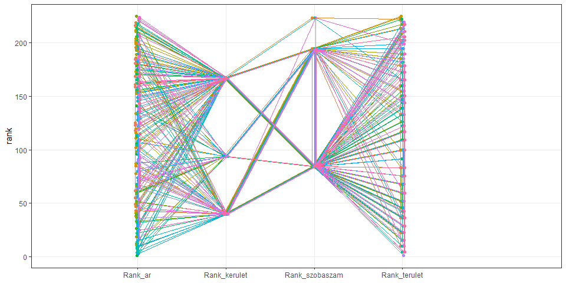

```r
if (!require('ggrepel')) install.packages('ggrepel'); library('ggrepel')
plotdata <- melt(Decision.Alternatives.1.Rank, id.vars = c("TELJES_CIM"))

plotdata$variable <- str_remove(plotdata$variable, pattern = "Rank ")

plotdata$variable <- factor(plotdata$variable)

ggplot(plotdata, aes(x = variable, y = value, colour = `TELJES_CIM`, group = `TELJES_CIM`, label = `TELJES_CIM`)) +
  geom_point(position = position_dodge(width = 0.05)) +
  geom_line(position = position_dodge(width = 0.05)) +
  #geom_text(data = plotdata[plotdata$variable == "NEGYZETMETER_AR", ], hjust = 1.2, vjust = -0.2, size = 2) +
  #geom_text_repel(data = plotdata[plotdata$variable == "TERULET", ], hjust = 1.2, vjust = 2.2, size = 2) +
  scale_x_discrete(expand = c(0.3, 0.3, 0.5, 0.3)) +
  labs(x = NULL, y = "rank") +
  theme_bw() +
  theme(legend.position = "none", panel.grid.minor = element_blank())
```

### Összesített rank kalkulációja

… Az egyes sorendekből egy összesített sorrendet számítunk ki, majd ebből kiszűrük a legjobb 10-et és ábrázoljuk. Ez már egy a döntést hatékonyan megtámogató eredmény.

```r
Decision.Alternatives.1.Rank$`Overall Rank` <-  rank(rowSums(subset(Decision.Alternatives.1.Rank, select = -c(`TELJES_CIM`)), dims = 1), ties.method = "average")

plotdata <- subset(Decision.Alternatives.1.Rank, `Overall Rank` <= 10)

DT::datatable(plotdata)
```

|  | TELJES_CIM | Rank_ar | Rank_terulet | Rank_szobaszam | Rank_kerulet | Overall Rank |
| --- | --- | --- | --- | --- | --- | --- |
| 1 | Budapest Julianus barát utca | 32 | 15.5 | 84.5 | 40 | 8.5 |
| 2 | Budapest Lőportár utca 1-3. | 15 | 29 | 84.5 | 40 | 7 |
| 3 | Budapest Pannónia utca 77-79 | 3 | 29 | 84.5 | 40 | 3 |
| 4 | Budapest Szobor utca 2-10 | 18 | 10 | 84.5 | 40 | 2 |
| 5 | Budapest Kassák Lajos utca 69 | 14 | 22.5 | 84.5 | 40 | 4 |
| 6 | Budapest Teve utca 27 | 17 | 22.5 | 84.5 | 40 | 6 |
| 7 | Budapest Teve utca 27 | 25 | 22.5 | 84.5 | 40 | 8.5 |
| 8 | Budapest Rozsnyai utca 31 | 36 | 1 | 84.5 | 40 | 5 |
| 9 | Budapest Frangepán köz | 33 | 15.5 | 84.5 | 40 | 10 |
| 10 | Budapest Kucsma utca | 5 | 15.5 | 84.5 | 40 | 1 |

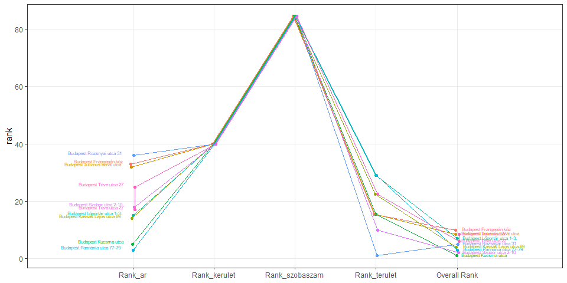

```r
plotdata <- reshape2::melt(plotdata, id.vars = c("TELJES_CIM"))

plotdata$variable <- str_remove(plotdata$variable, pattern = "Rank ")

plotdata$variable <- factor(plotdata$variable, levels = c("Rank_ar", "Rank_kerulet", "Rank_szobaszam", "Rank_terulet", "Overall Rank"))

ggplot(plotdata, aes(x = variable, y = value, colour = `TELJES_CIM`, group = `TELJES_CIM`, label = `TELJES_CIM`)) +
  geom_point(position = position_dodge(width = 0.05)) +
  geom_line(position = position_dodge(width = 0.05)) +
  geom_text(data = plotdata[plotdata$variable == "Rank_ar", ], hjust = 1.2, vjust = -0.2, size = 2) +
  geom_text(data = plotdata[plotdata$variable == "Overall Rank", ], hjust = -0.1, vjust = 0.2, size = 2) +
  scale_x_discrete(expand = c(0.3, 0.1, 0.3, 0.1)) +
  labs(x = NULL, y = "rank") +
  theme_bw() +
  theme(legend.position = "none", panel.grid.minor = element_blank())
```

```r
selection.rank.1 <- unique(plotdata$`TELJES_CIM`)
selection.rank.1
```

```
[1] "Budapest Julianus barát utca"  "Budapest Lőportár utca 1-3."   "Budapest Pannónia utca 77-79"  "Budapest Szobor utca 2-10"
[5] "Budapest Kassák Lajos utca 69" "Budapest Teve utca 27"         "Budapest Rozsnyai utca 31"     "Budapest Frangepán köz"
[9] "Budapest Kucsma utca"
```

## Normalizáció

Szeretnénk tovább javítani a modellünket, ezért az egyes alternatívák jobb összehasonlítása érdekében normalizáljuk az adatokat. A legegyszerűbb, legtöbbet használt normalizációs módszert fogjk alkalmazni (vi=ai/max ai).Lépések: a függvény definiálása, az oszlopnevek kimentése, az irányok (kisebb / nagyobb az előnyös) meghatározása, a számítás elvégzése (ehhez a maximumok és minimumok letárolása).

```r
norm1 <- function(x) {
    x / max(x)}

change.direction <- function(x, y) {
  ifelse(y == -1, 1 + x * y, x)
}
```

```r
Decision.Alternatives.1 <- Decision.Alternatives.1[,c(1:6)]

Decision.Alternatives.1.Teljes_cim <- Decision.Alternatives.1$`TELJES_CIM`

Decision.Alternatives.1.matrix <- subset(Decision.Alternatives.1, select = - c(`TELJES_CIM`))

Decision.Alternatives.1.ids <- subset(Decision.Alternatives.1, select = c(`TELJES_CIM`))

Decision.Alternatives.1.rownames <- rownames(Decision.Alternatives.1.matrix)
Decision.Alternatives.1.colnames <- colnames(Decision.Alternatives.1.matrix)
```

```r
Decision.Alternatives.1.Direction <- c(-1, -1, 1, 1, 1)
```

```r
Decision.Alternatives.1.norm1 <- as.data.frame(apply(Decision.Alternatives.1.matrix, MARGIN = 2, norm1))

Decision.Alternatives.1.norm1 <- as.data.frame(t(apply(Decision.Alternatives.1.norm1, MARGIN = 1, FUN = change.direction, y =  Decision.Alternatives.1.Direction)))


colnames(Decision.Alternatives.1.norm1) <- Decision.Alternatives.1.colnames

Decision.Alternatives.1.norm1$Overall <- rowMeans(Decision.Alternatives.1.norm1)
Decision.Alternatives.1.norm1 <- cbind(Decision.Alternatives.1.ids, Decision.Alternatives.1.norm1)

Overall.max.1 <- max(Decision.Alternatives.1.norm1$Overall)
Overall.min.1 <- min(Decision.Alternatives.1.norm1$Overall)
```

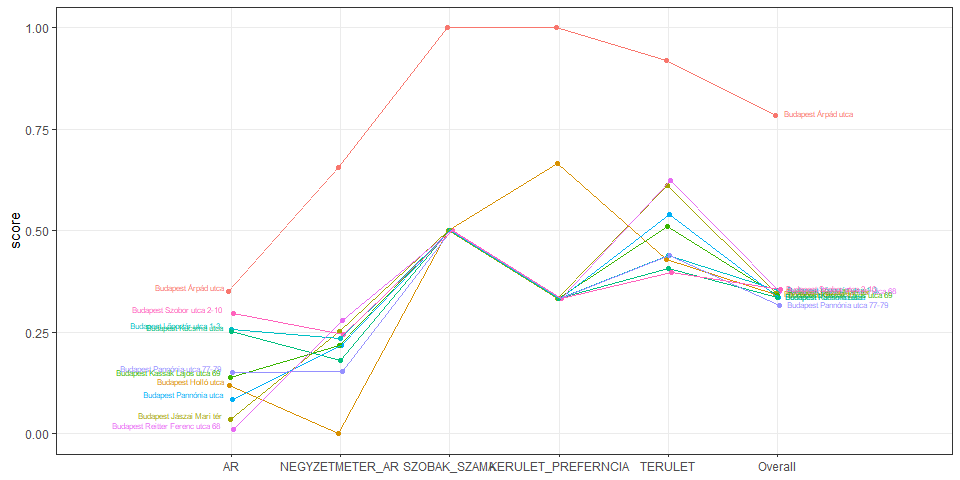

```r
plotdata <- subset(Decision.Alternatives.1.norm1, `Overall` >= (Overall.max.1 - Overall.max.1 * 0.05) | `Overall` <= (Overall.min.1 + Overall.max.1 * 0.05))

plotdata <- reshape2::melt(plotdata, id.vars = c("TELJES_CIM"))


ggplot(plotdata, aes(x = variable, y = value, group = `TELJES_CIM`, label = `TELJES_CIM`, colour = as.factor(`TELJES_CIM`))) +
  geom_point(position = position_dodge(width = 0.05)) +
  geom_line(position = position_dodge(width = 0.05)) +
  geom_text(data = plotdata[plotdata$variable == "AR", ], hjust = 1.1, vjust = -0.2, size = 2) +
  geom_text(data = plotdata[plotdata$variable == "Overall", ], hjust = -0.1, vjust = 0.2, size = 2) +
  scale_x_discrete(expand = c(0.3, 0.1, 0.3, 0.1)) +
  labs(x = NULL, y = "score") +
  theme_bw() +
  theme(legend.position = "none", panel.grid.minor = element_blank())
```

Ha össze akárnánk vetni az előző módszer eredményével, a ugyanarra a tíz lakásra leszűrve:

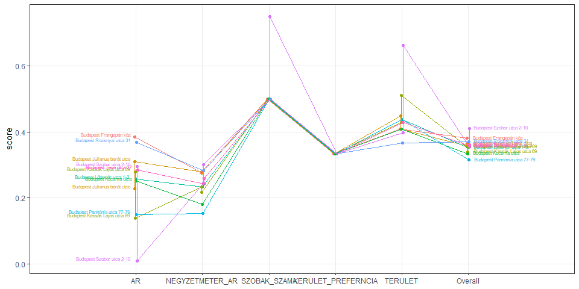

```r
plotdata <- subset(Decision.Alternatives.1.norm1, `TELJES_CIM` %in% selection.rank.1)

plotdata <- reshape2::melt(plotdata, id.vars = c("TELJES_CIM"))



ggplot(plotdata, aes(x = variable, y = value, group = `TELJES_CIM`, label = `TELJES_CIM`, colour= as.factor(`TELJES_CIM`))) +
  geom_point(position = position_dodge(width = 0.05)) +
  geom_line(position = position_dodge(width = 0.05)) +
  geom_text(data = plotdata[plotdata$variable == "AR", ], hjust = 1.1, vjust = -0.2, size = 2) +
  geom_text(data = plotdata[plotdata$variable == "Overall", ], hjust = -0.1, vjust = 0.2, size = 2) +
  scale_x_discrete(expand = c(0.3, 0.1, 0.3, 0.1)) +
  labs(x = NULL, y = "score") +
  theme_bw() +
  theme(legend.position = "none", panel.grid.minor = element_blank())
```

### Súlyozzuk a döntési kritériumokat

Modellünket úgy változtatjuk, hogy meghatározzuk a fent tekintetbe vett 5 szempont súlyát. Az összes szempont együttes súlya egy. Ezt egy vetorban határozzuk meg, majd ezzel súlyozzuk be az egyes (már normalizált) szempontokat, így állítunk elő egy új összesített sorrendet. A legfontosabbnak a négyzetméterárat gondoltam, majd a lokáció és a szobák száma következik.

```r
d_weights <- c(0.1, 0.3, 0.2, 0.25, 0.15)


Decision.Alternatives.1.weight_norm1 <- subset(Decision.Alternatives.1.norm1, select = -c(Overall))

Decision.Alternatives.1.weight_norm1$overall <- Decision.Alternatives.1.weight_norm1$AR * d_weights[1] + Decision.Alternatives.1.weight_norm1$NEGYZETMETER_AR * d_weights[2] +
  Decision.Alternatives.1.weight_norm1$SZOBAK_SZAMA * d_weights[3] +
  Decision.Alternatives.1.weight_norm1$KERULET_PREFERNCIA * d_weights[4] +
  Decision.Alternatives.1.weight_norm1$TERULET * d_weights[5]
```

Jelenítsük meg a súlyozott döntési eredményünket grafikonon, illetve egy adattáblában. A grafikonra csak a legjobb 10 választást szűrjük le az átláthatóság miatt.

```r
Decision.Alternatives.1.weight_norm1$overall_rank <-  rank(Decision.Alternatives.1.weight_norm1$overall)

DT::datatable(Decision.Alternatives.1.weight_norm1)
```

|  | TELJES_CIM | AR | NEGYZETMETER_AR | SZOBAK_SZAMA | KERULET_PREFERNCIA | TERULET | overall | overall_rank |
| --- | --- | --- | --- | --- | --- | --- | --- | --- |
| 1 | Budapest Fillér utca | 0.16819469911652 | 0.328505848241082 | 0.5 | 0.666666666666667 | 0.602040816326531 | 0.472344013499623 | 68 |
| 2 | Budapest Fekete Sas utca | 0.166694449074846 | 0.325580139798845 | 0.5 | 0.666666666666667 | 0.591836734693878 | 0.469785663717886 | 66 |
| 3 | Budapest Margit körút | 0.00150025004167365 | 0.36164217593313 | 0.75 | 0.666666666666667 | 0.73469387755102 | 0.535513426083426 | 111 |
| 4 | Budapest Szomolnok utca 11 | 0.584930821803634 | 0.550696136000584 | 0.5 | 0.666666666666667 | 0.448979591836735 | 0.557715528422716 | 132 |
| 5 | Budapest Nánási út | 0.0833472245374229 | 0.401926442052712 | 0.75 | 0.666666666666667 | 0.744897959183674 | 0.557314015613773 | 130 |
| 6 | Budapest Csillaghegy | 0.334889148191365 | 0.413358538622527 | 0.5 | 0.666666666666667 | 0.551020408163265 | 0.506816204297051 | 88 |
| 7 | Budapest Harrer Pál utca | 0.441573595599267 | 0.46805301050238 | 0.5 | 0.666666666666667 | 0.489795918367347 | 0.524709317132409 | 100 |
| 8 | Budapest Madzsar József utca 27 | 0.299883313885648 | 0.598241875502174 | 0.5 | 0.666666666666667 | 0.826530612244898 | 0.600107152542618 | 155 |
| 9 | Budapest Lukács György utca | 0.466744457409568 | 0.520783248274745 | 0.5 | 0.666666666666667 | 0.520408163265306 | 0.547637311379843 | 123 |
| 10 | Budapest Hunor utca 26 | 0.253208868144691 | 0.370460586697832 | 0.5 | 0.666666666666667 | 0.540816326530612 | 0.484248178470077 | 77 |

[output cut: 215 more lines]

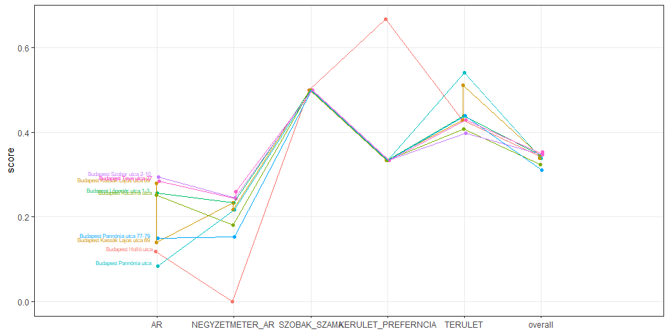

```r
plotdata <- subset(Decision.Alternatives.1.weight_norm1, select = -c(overall_rank), `overall_rank` <= 10)

plotdata <- reshape2::melt(plotdata, id.vars = c("TELJES_CIM"))

ggplot(plotdata, aes(x = variable, y = value, group = `TELJES_CIM`, label = `TELJES_CIM`, colour = as.factor(`TELJES_CIM`))) +
  geom_point(position = position_dodge(width = 0.05)) +
  geom_line(position = position_dodge(width = 0.05)) +
  geom_text(data = plotdata[plotdata$variable == "AR", ], hjust = 1.1, vjust = -0.2, size = 2) +
  geom_text(data = plotdata[plotdata$variable == "Overall", ], hjust = -0.1, vjust = 0.2, size = 2) +
  scale_x_discrete(expand = c(0.3, 0.1, 0.3, 0.1)) +
  labs(x = NULL, y = "score") +
  theme_bw() +
  theme(legend.position = "none", panel.grid.minor = element_blank())
```

Vessük össze, hogy a súlyozott ranking és a korábbi összesített sorrend alapján kiválasztott 10 legjobb választás mennyire esik egybe? Az eredmények azt mutatják, hogy a legjobb 10 közül 8 már a korábbi listánkon is szerepelt. Valószínűleg ezeket a lehetőségeket kellene különösen figyelembe vennünk a tényleges döntés során. Mivel egy nagy értékű beruházásól van szó, ezen 10 legjobbank gondolt/számolt lakást érdemes megtekinteni, és a többi, itt nem szereplő egyéb adat mérlegelése után szerencsés meghozni a végső döntést.

```r
list_overall_rank <- as.data.frame(subset(Decision.Alternatives.1.weight_norm1, select = c(overall_rank, `TELJES_CIM`), overall_rank<=10))
list_overall_rank
```

|  | overall_rank | TELJES_CIM |
| --- | --- | --- |
| 65 | 5 | Budapest Holló utca |
| 137 | 6 | Budapest Lőportár utca 1-3. |
| 148 | 3 | Budapest Pannónia utca |
| 151 | 1 | Budapest Pannónia utca 77-79 |
| 164 | 8 | Budapest Szobor utca 2-10 |
| 168 | 7 | Budapest Kassák Lajos utca 69 |
| 169 | 4 | Budapest Kassák Lajos utca 69 |
| 173 | 9 | Budapest Teve utca 27 |
| 174 | 10 | Budapest Teve utca 27 |
| 186 | 2 | Budapest Kucsma utca |

```r
list_overall_rank2 <- subset(list_overall_rank, `TELJES_CIM` %in% selection.rank.1)
list_overall_rank2
```

|  | overall_rank | TELJES_CIM |
| --- | --- | --- |
| 137 | 6 | Budapest Lőportár utca 1-3. |
| 151 | 1 | Budapest Pannónia utca 77-79 |
| 164 | 8 | Budapest Szobor utca 2-10 |
| 168 | 7 | Budapest Kassák Lajos utca 69 |
| 169 | 4 | Budapest Kassák Lajos utca 69 |
| 173 | 9 | Budapest Teve utca 27 |
| 174 | 10 | Budapest Teve utca 27 |
| 186 | 2 | Budapest Kucsma utca |